# PCA simulations

Giuseppe D’Agostino

# Intro

This exercise wants to answer a simple question: how does the principal component 1 of a PCA analysis change if I keep adding to my sample pool different cell types?

# Function for data simulation

We will use the [code](https://jef.works/blog/2018/02/28/stability-testing/) from Jean Fan’s MUDAN package, in which she has created a simple count data simulator for RNA-seq:

```r
#' Simulate gene expression counts counts
#' @param G number of groups
#' @param N number of cells per group
#' @param M number of genes
#' @param initmean default mean gene expression
#' @param initvar default gene expression variance
#' @param upreg gene expression increase for upregulated genes
#' @param upregvar gene expression variance for upregulated genes
#' @param ng number of upregulated genes per group
#' @author Jean Fan
simulate.data <- function(G=5, N=30, M=100, initmean=0, initvar=10, upreg=10, upregvar=10, ng=20, seed=0) {
    set.seed(seed)
    mat <- matrix(rnorm(N*M*G, initmean, initvar), M, N*G)
    rownames(mat) <- paste0('gene', 1:M)
    colnames(mat) <- paste0('cell', 1:(N*G))
    group <- factor(sapply(1:G, function(x) rep(paste0('group', x), N)))
    names(group) <- colnames(mat)

    diff <- lapply(1:G, function(x) {
        diff <- rownames(mat)[(((x-1)*ng)+1):(((x-1)*ng)+ng)]
        mat[diff, group==paste0('group', x)] <<- mat[diff, group==paste0('group', x)] + rnorm(ng, upreg, upregvar)
        return(diff)
    })
    names(diff) <- paste0('group', 1:G)

    mat[mat<0] <- 0
    mat <- round(mat)

    return(list(cd=mat, group=group))
}
```

We also load the plot_PCA_2 function from my helpers:

```r
plot_PCA_2 <- function(data, comp1, comp2, coldata, colors, symbol, ntop = 500, lab1 = NA, lab2 = NA, ...){
    rv <- matrixStats::rowVars(data)
    select <- order(rv, decreasing = TRUE)[seq_len(min(ntop,length(rv)))]
    pca_all <- (prcomp(t(data[select,])))
    pca_all_data <- pca_all$x
  pca_all_data <- cbind(as.data.frame(pca_all_data), coldata)
  percentVar <- pca_all$sdev^2 / sum(pca_all$sdev^2)
  plot(pca_all_data[,comp1], pca_all_data[,comp2], col=colors, pch=symbol, xlab=paste("PC", comp1, ": ", round(percentVar[comp1], 2)*100, "% variance", sep=""), ylab=paste("PC", comp2, ": ", round(percentVar[comp2], 2)*100, "% variance", sep=""), ...)
    text(pca_all_data[,comp1], pca_all_data[,comp2], pos=2, cex=0.7, labels=lab1)
    text(pca_all_data[,comp1], pca_all_data[,comp2], pos=4, cex=0.7, labels=lab2)
}
```

# Let’s do it

Let’s start by simulating 2 pools of 10 cells each, with 5000 genes, out of which 1000 are differentially expressed, and plotting the PCA:

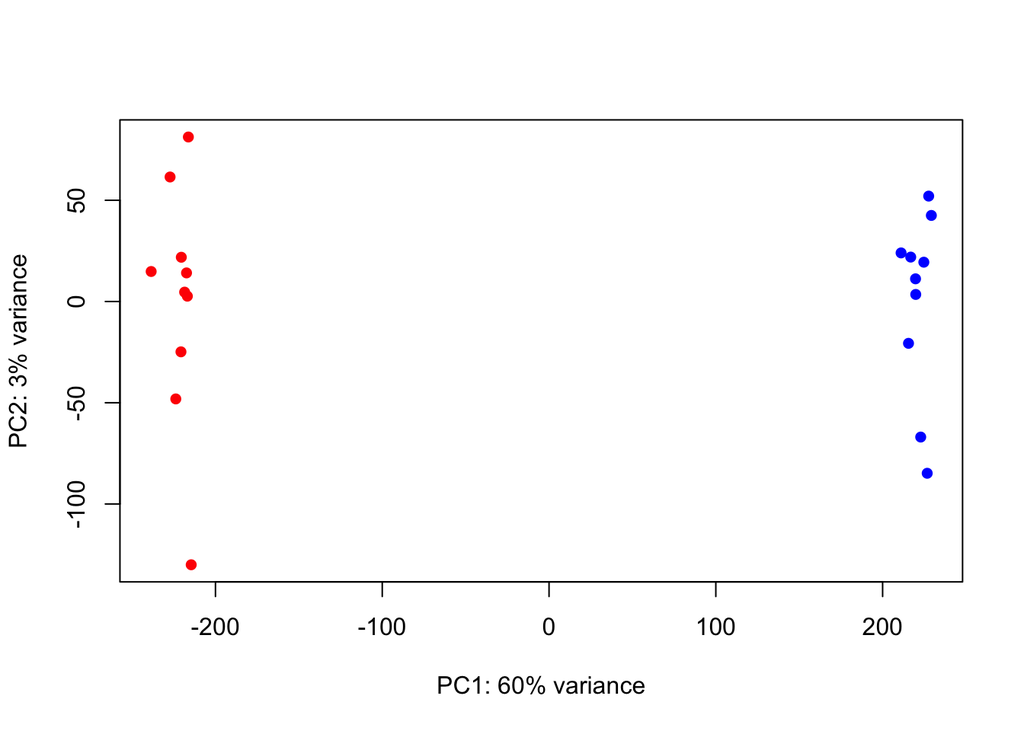

```r
library(gplots)
data_1 = simulate.data(G = 2, N = 10, M = 5000, ng = 1000)

dat = data_1$cd
coldata = data.frame(sample = colnames(dat), stringsAsFactors = F)
coldata$group = data_1$group
coldata$color = rep(c("red", "blue"), each = 10)
rownames(coldata) = coldata$sample
plot_PCA_2(dat, 1, 2, coldata, colors = coldata$color, symbol = 16)
```

What happens if we decrease the number of DEGs to the half?

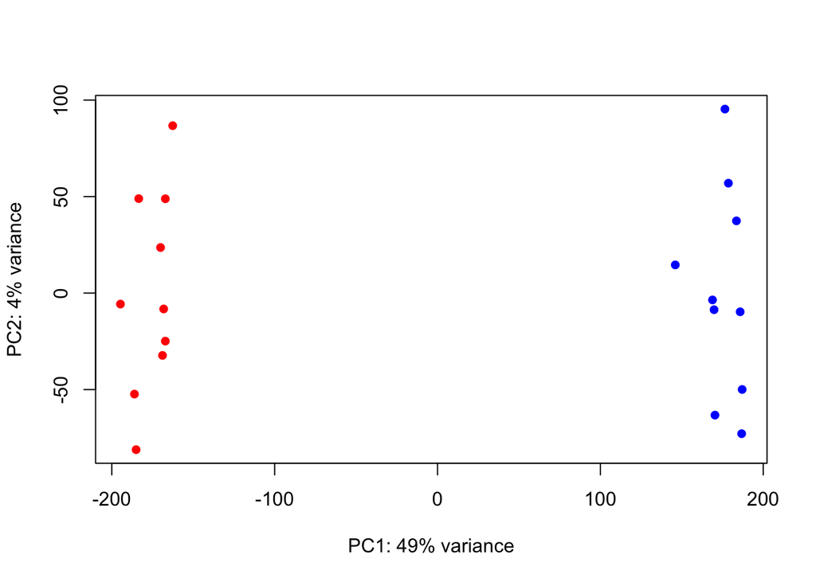

```r
data_2 = simulate.data(G = 2, N = 10, M = 5000, ng = 500)

dat = data_2$cd
coldata = data.frame(sample = colnames(dat), stringsAsFactors = F)
coldata$group = data_2$group
coldata$color = rep(c("red", "blue"), each = 10)
rownames(coldata) = coldata$sample
plot_PCA_2(dat, 1, 2, coldata, colors = coldata$color, symbol = 16)
```

As expected, there is a decrease in variance along PC1.

What happens if we add a group that has 500 more differentially expressed genes?

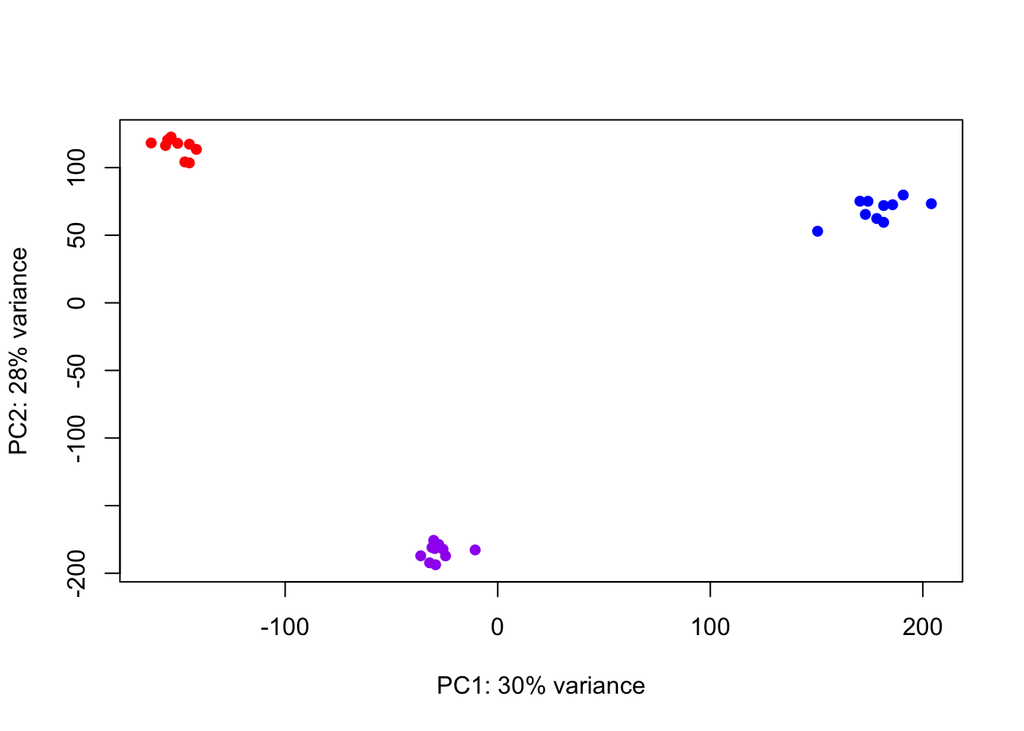

```r
data_3 = simulate.data(G = 3, N = 10, M = 5000, ng = 500)
dat = data_3$cd
coldata = data.frame(sample = colnames(dat), stringsAsFactors = F)
coldata$group = data_3$group
coldata$color = rep(c("red", "blue", "purple"), each = 10)
rownames(coldata) = coldata$sample
plot_PCA_2(dat, 1, 2, coldata, colors = coldata$color, symbol = 16)
```

Note that for how the simulate.data function is constructed, these will be 500 different genes (every group will have its own set of unique DEGs compared to the other ones)

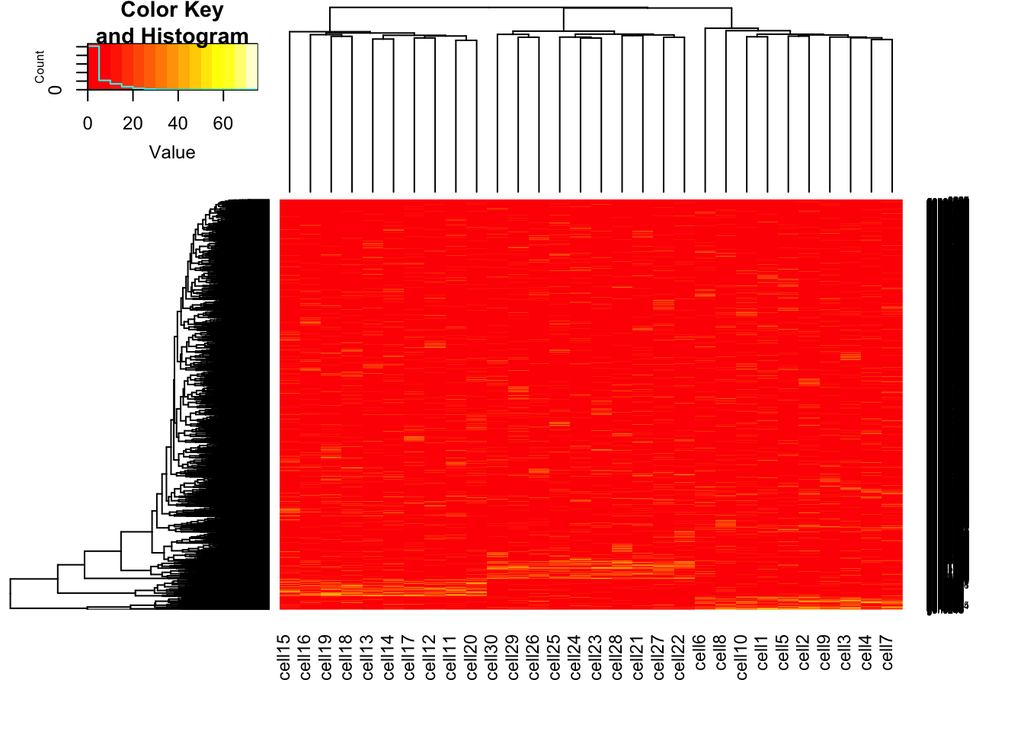

```r
heatmap.2(dat, trace = "none")
```

And what happens if we increase the number of DEGs?

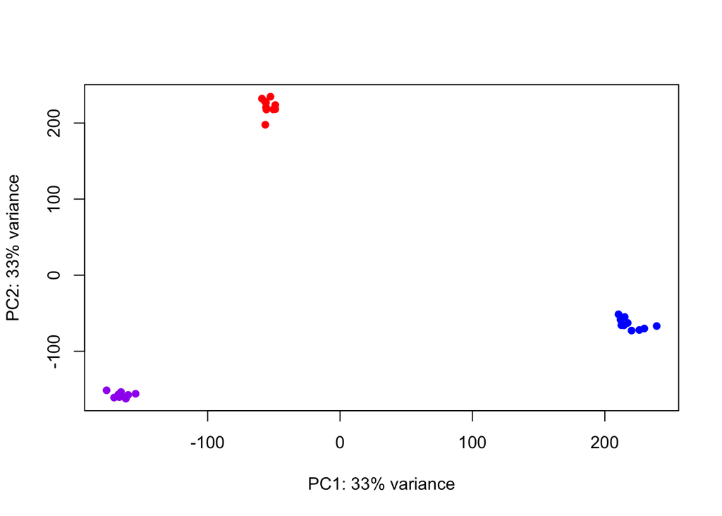

```r
data_4 = simulate.data(G = 3, N = 10, M = 5000, ng = 1000)
dat = data_4$cd
coldata = data.frame(sample = colnames(dat), stringsAsFactors = F)
coldata$group = data_4$group
coldata$color = rep(c("red", "blue", "purple"), each = 10)
rownames(coldata) = coldata$sample
plot_PCA_2(dat, 1, 2, coldata, colors = coldata$color, symbol = 16)
```

And if we add another group?

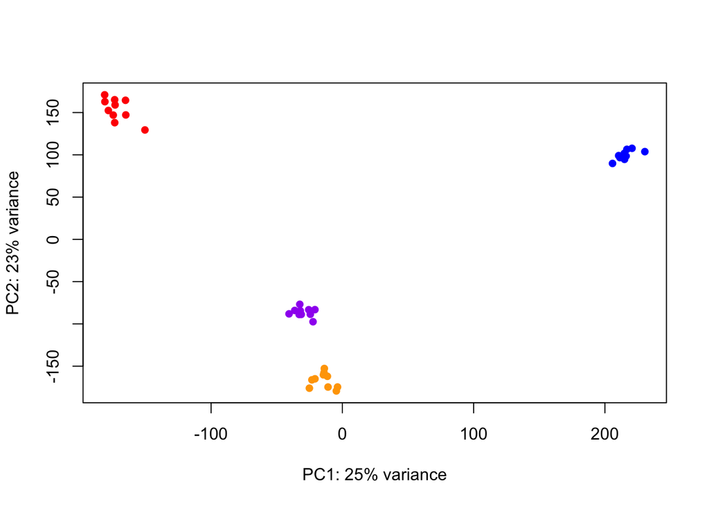

```r
data_5 = simulate.data(G = 4, N = 10, M = 5000, ng = 1000)
dat = data_5$cd
coldata = data.frame(sample = colnames(dat), stringsAsFactors = F)
coldata$group = data_5$group
coldata$color = rep(c("red", "blue", "purple", "orange"), each = 10)
rownames(coldata) = coldata$sample
plot_PCA_2(dat, 1, 2, coldata, colors = coldata$color, symbol = 16)
```

# Okay, you were right

In conclusion, the more groups are added, even in the case where the group is really different (since the DEGs are specific to a group and not to any other groups), the less variability PC1 can capture, since differences will be orthogonal and will be reflected in different PCs (see for instance how PC2 captures better the differences between the purple group and the red group than PC1). Maybe I should study more how PCA works :O

Well played Ale!